# Using Machine Learning For NBA Shot Prediction - Part 2

## Featuring Stephen Curry, James Harden & LeBron James: 2017-2018 NBA Season

### Predicting 'in-the-moment' shot probability

#### Author: Tim Flocke

Part 1 detailed the data ingestion, cleaning, feature engineering, and exploratory visualization of the NBA data. The data is derived from a full season of NBA play level data, but was filtered to include only shots attempted by Steph Curry, James Harden or LeBron James. The original data represented over a half-million records, however was filtered using

> players = ['LeBron James', 'Stephen Curry', 'James Harden']

> nba = nba[nba.player.isin(players) & (nba.result != '')]

Now, the objective is to train a machine learning model that can predict whether a shot attempt will be 'made' or 'missed'. The concept is to use a probabilistic model to both make a binary prediction and extract the probability of making the shot 'in-the-moment' by using variables which capture (at least in part) the psychological components of the game at the time the shot was taken. As an example, consider the fact that a shot attempted in the 4th quarter of a playoff game when the player's team is down by 6 points may have less probability of success than a first quarter regular season game when the player is up several points.

The input variables for the shot prediction model will be type, shot_distance, playoff, assisted, isAway, winning, spread, three, and period. The response variable is result_flag, with '1' indicating the shot was made, '0' indicating a miss.

```python
import pandas as pd
import numpy as np
import plotly.express as px
import plotly.graph_objects as go
```

```python
nba = pd.read_csv('../NBA/curry_james_harden_preprocessed.csv').fillna('')
nba.head(1).transpose()
```

|  | 0 |
| --- | --- |
| game_id | 21700001 |
| data_set | 2017-2018 Regular Season |
| date | 10/17/2017 |
| a1 | Jayson Tatum |
| a2 | Al Horford |
| a3 | Jaylen Brown |
| a4 | Kyrie Irving |
| a5 | Marcus Smart |
| h1 | LeBron James |
| h2 | Jae Crowder |
| h3 | Dwyane Wade |
| h4 | Derrick Rose |
| h5 | Tristan Thompson |
| period | 1 |
| away_score | 12 |
| home_score | 9 |
| remaining_time | 0:06:26 |
| elapsed | 0 days 00:05:34.000000000 |
| play_length | 0:00:19 |
| play_id | 72 |
| team | CLE |
| event_type | miss |
| assist |  |
| away |  |
| home |  |
| block |  |
| entered |  |
| left |  |
| num |  |
| opponent |  |
| outof |  |
| player | LeBron James |
| points | 0 |
| possession |  |
| reason |  |
| result | missed |
| steal |  |
| type | jump_shot |
| shot_distance | 17 |
| original_x | 92 |
| original_y | 143 |
| converted_x | 34.2 |
| converted_y | 74.7 |
| description | MISS James 17' Turnaround Fadeaway Bank Jump Shot |
| playoff | 0 |
| assisted | 0 |
| result_flag | 0 |
| result_flag_0 | 1 |
| result_flag_1 | 0 |
| game_time | 0 days 00:05:34.000000000 |
| cumulative_made | 0 |
| cumulative_missed | 1 |
| game_shot_pct | 0 |
| shots_taken | 1 |
| isAway | 0 |
| winning | away |
| spread | -3 |
| three | 0 |

Game time is transformed into a timedelta:

```python
from datetime import date, datetime, time, timedelta
nba['game_time'] = pd.to_timedelta(nba.game_time)
nba['game_time'].head()
```

```
0   00:05:34
1   00:06:16
2   00:07:29
3   00:16:32
4   00:16:43
Name: game_time, dtype: timedelta64[ns]
```

Subset dataframe fields:

```python
df = nba[['play_id', 'player', 'spread', 'shot_distance', 'type', 'playoff', 'assisted', 'isAway', 'winning',  'three', 'period', 'game_shot_pct', 'cumulative_made', 'cumulative_missed', 'result_flag']]
df.sample(5, random_state=0)
```

|  | play_id | player | spread | shot_distance | type | playoff | assisted | isAway | winning | three | period | game_shot_pct | cumulative_made | cumulative_missed | result_flag |
| --- | --- | --- | --- | --- | --- | --- | --- | --- | --- | --- | --- | --- | --- | --- | --- |
| 2200 | 9 | LeBron James | 2.0 | 10 | jump_shot | 0 | 0 | 1 | away | 0 | 1 | 1.000000 | 1 | 0 | 1 |
| 5022 | 27 | James Harden | 4.0 | 15 | free_throw | 0 | 0 | 0 | home | 0 | 1 | 1.000000 | 1 | 0 | 1 |
| 6266 | 545 | Stephen Curry | 7.0 | 26 | jump_shot | 1 | 0 | 1 | away | 1 | 4 | 0.466667 | 7 | 8 | 0 |
| 2830 | 257 | Stephen Curry | 19.0 | 25 | jump_shot | 0 | 0 | 1 | away | 1 | 2 | 0.250000 | 1 | 3 | 0 |
| 4821 | 83 | James Harden | -2.0 | 15 | free_throw | 0 | 0 | 1 | home | 0 | 1 | 0.583333 | 7 | 5 | 1 |

### One hot encoding

ML models require numeric inputs, so all categorical variables should be converted to binary indicator fields - one for each level. This is accomplished using a technique known as 'one-hot encoding' via the get_dummies() pandas function:

```python
df = pd.get_dummies(data=df, columns=['type', 'playoff', 'assisted', 'isAway', 'winning', 'three', 'period'])
df.sample(5, random_state=0)
```

|  | play_id | player | spread | shot_distance | game_shot_pct | cumulative_made | cumulative_missed | result_flag | type_dunk | type_free_throw | ... | winning_away | winning_home | winning_tied | three_0 | three_1 | period_1 | period_2 | period_3 | period_4 | period_5 |
| --- | --- | --- | --- | --- | --- | --- | --- | --- | --- | --- | --- | --- | --- | --- | --- | --- | --- | --- | --- | --- | --- |
| 2200 | 9 | LeBron James | 2.0 | 10 | 1.000000 | 1 | 0 | 1 | 0 | 0 | ... | 1 | 0 | 0 | 1 | 0 | 1 | 0 | 0 | 0 | 0 |
| 5022 | 27 | James Harden | 4.0 | 15 | 1.000000 | 1 | 0 | 1 | 0 | 1 | ... | 0 | 1 | 0 | 1 | 0 | 1 | 0 | 0 | 0 | 0 |
| 6266 | 545 | Stephen Curry | 7.0 | 26 | 0.466667 | 7 | 8 | 0 | 0 | 0 | ... | 1 | 0 | 0 | 0 | 1 | 0 | 0 | 0 | 1 | 0 |
| 2830 | 257 | Stephen Curry | 19.0 | 25 | 0.250000 | 1 | 3 | 0 | 0 | 0 | ... | 1 | 0 | 0 | 0 | 1 | 0 | 1 | 0 | 0 | 0 |
| 4821 | 83 | James Harden | -2.0 | 15 | 0.583333 | 7 | 5 | 1 | 0 | 1 | ... | 0 | 1 | 0 | 1 | 0 | 1 | 0 | 0 | 0 | 0 |

5 rows × 30 columns

```python
from sklearn.metrics import accuracy_score
from sklearn.metrics import confusion_matrix
from sklearn.metrics import f1_score
from sklearn.metrics import classification_report

import matplotlib.pyplot as plt
fig = plt.figure(figsize = (6,6))
import seaborn as sns
```

```python
from sklearn.model_selection import train_test_split
from sklearn.model_selection import cross_val_score

from sklearn.linear_model import LogisticRegression
from sklearn.naive_bayes import MultinomialNB
from sklearn.ensemble import RandomForestClassifier
from sklearn.svm import LinearSVC
from sklearn.neighbors import KNeighborsClassifier
from sklearn.svm import SVC
from sklearn.svm import SVR
from sklearn.svm import LinearSVR
from sklearn.ensemble import GradientBoostingClassifier
from sklearn.naive_bayes import GaussianNB

from sklearn.decomposition import PCA
```

### Analyze Shot Result

The target variable 'result_flag' is slightly imbalanced. There is a roughly 60/40 split between made shots and missed shots for all players. The imbalance logically indicates that these players 'make' more than they 'miss'... which explains the high salaries and why their teams tend to win more than they lose.

```python
display(df.result_flag.value_counts())

print("Perecent of shots made:", len(df[df.result_flag == 1])/len(df))
print("Perecent of shots missed:", len(df[df.result_flag != 1])/len(df))
```

```
1    4118
0    2926
Name: result_flag, dtype: int64
```

```
Perecent of shots made: 0.5846110164679159
Perecent of shots missed: 0.41538898353208403
```

### Scale Numeric Variables

```python
from sklearn.preprocessing import MinMaxScaler

# float conversion
cols = ['spread', 'shot_distance', 'cumulative_made', 'cumulative_missed']
df[cols] = df[cols].apply(pd.to_numeric, axis = 1)

# normalize the cols
mms = MinMaxScaler()
scaled_vars = mms.fit_transform(df[cols])
df[cols] = pd.DataFrame(scaled_vars)

df[cols].head()
```

|  | spread | shot_distance | cumulative_made | cumulative_missed |
| --- | --- | --- | --- | --- |
| 0 | 0.438356 | 0.226667 | 0.000000 | 0.043478 |
| 1 | 0.465753 | 0.293333 | 0.027778 | 0.043478 |
| 2 | 0.493151 | 0.013333 | 0.055556 | 0.043478 |
| 3 | 0.602740 | 0.306667 | 0.055556 | 0.086957 |
| 4 | 0.630137 | 0.013333 | 0.083333 | 0.086957 |

### Define Predictors

The cumulative missed and cumulative made fields were considered, howerver the game_shot_percentage is a proportion of both, and inclusion of all or both would likely introduce multicolinearity.

```python
predictors = ['spread', 'shot_distance', 'game_shot_pct',
              'type_dunk', 'type_free_throw', 'type_hook_shot', 'type_jump_shot', 'type_layup', 'type_turnaround_fadeaway',
              'playoff_0', 'playoff_1',
              'assisted_0', 'assisted_1',
              'isAway_0', 'isAway_1',
              'winning_away', 'winning_home', 'winning_tied',
              'three_0', 'three_1',
              'period_1', 'period_2', 'period_3', 'period_4', 'period_5']

players = df.player.unique()
```

```python
df.columns
```

```
Index(['play_id', 'player', 'spread', 'shot_distance', 'game_shot_pct',
       'cumulative_made', 'cumulative_missed', 'result_flag', 'type_dunk',
       'type_free_throw', 'type_hook_shot', 'type_jump_shot', 'type_layup',
       'type_turnaround_fadeaway', 'playoff_0', 'playoff_1', 'assisted_0',
       'assisted_1', 'isAway_0', 'isAway_1', 'winning_away', 'winning_home',
       'winning_tied', 'three_0', 'three_1', 'period_1', 'period_2',
       'period_3', 'period_4', 'period_5'],
      dtype='object')
```

```python
df[predictors].head().transpose()
```

|  | 0 | 1 | 2 | 3 | 4 |
| --- | --- | --- | --- | --- | --- |
| spread | 0.438356 | 0.465753 | 0.493151 | 0.602740 | 0.630137 |
| shot_distance | 0.226667 | 0.293333 | 0.013333 | 0.306667 | 0.013333 |
| game_shot_pct | 0.000000 | 0.500000 | 0.666667 | 0.500000 | 0.600000 |
| type_dunk | 0.000000 | 0.000000 | 0.000000 | 0.000000 | 0.000000 |
| type_free_throw | 0.000000 | 0.000000 | 0.000000 | 0.000000 | 0.000000 |
| type_hook_shot | 0.000000 | 0.000000 | 0.000000 | 0.000000 | 0.000000 |
| type_jump_shot | 1.000000 | 1.000000 | 0.000000 | 1.000000 | 0.000000 |
| type_layup | 0.000000 | 0.000000 | 1.000000 | 0.000000 | 1.000000 |
| type_turnaround_fadeaway | 0.000000 | 0.000000 | 0.000000 | 0.000000 | 0.000000 |
| playoff_0 | 1.000000 | 1.000000 | 1.000000 | 1.000000 | 1.000000 |
| playoff_1 | 0.000000 | 0.000000 | 0.000000 | 0.000000 | 0.000000 |
| assisted_0 | 1.000000 | 1.000000 | 1.000000 | 1.000000 | 0.000000 |
| assisted_1 | 0.000000 | 0.000000 | 0.000000 | 0.000000 | 1.000000 |
| isAway_0 | 1.000000 | 1.000000 | 1.000000 | 1.000000 | 1.000000 |
| isAway_1 | 0.000000 | 0.000000 | 0.000000 | 0.000000 | 0.000000 |
| winning_away | 1.000000 | 1.000000 | 0.000000 | 0.000000 | 0.000000 |
| winning_home | 0.000000 | 0.000000 | 1.000000 | 1.000000 | 1.000000 |
| winning_tied | 0.000000 | 0.000000 | 0.000000 | 0.000000 | 0.000000 |
| three_0 | 1.000000 | 1.000000 | 1.000000 | 0.000000 | 1.000000 |
| three_1 | 0.000000 | 0.000000 | 0.000000 | 1.000000 | 0.000000 |
| period_1 | 1.000000 | 1.000000 | 1.000000 | 0.000000 | 0.000000 |
| period_2 | 0.000000 | 0.000000 | 0.000000 | 1.000000 | 1.000000 |
| period_3 | 0.000000 | 0.000000 | 0.000000 | 0.000000 | 0.000000 |
| period_4 | 0.000000 | 0.000000 | 0.000000 | 0.000000 | 0.000000 |
| period_5 | 0.000000 | 0.000000 | 0.000000 | 0.000000 | 0.000000 |

### Choose modeling algorithm

Use cross validation to chose a reasonably effective 'out-of-the-box' model. This is done without care to fine-tune specific parameters. The process will test several potentially useful modeling types to see which might be the most optimal for this problem. Models are compared using the maximized F1 score

```python
models = [
    MultinomialNB(),
    RandomForestClassifier(n_estimators=20, random_state=0),
    LinearSVC(random_state=0),
    GradientBoostingClassifier(random_state=0),
    LogisticRegression(solver='liblinear', random_state=0)
]

CV = 10
cv_df = pd.DataFrame(index=range(CV * len(models)))

for player in players:

    X = df[df.player == player][predictors]
    y = df[df.player == player].result_flag

    X_train, X_test, y_train, y_test = train_test_split(X,
                                                        y,
                                                        test_size = 0.20,
                                                        shuffle = True,
                                                        stratify = y,
                                                        random_state = 0)

    entries = []
    for model in models:
        model_name = model.__class__.__name__
        metrics = cross_val_score(model, X_train, y_train, scoring='f1', cv=CV)

        for fold_idx, metric in enumerate(metrics):
            entries.append((model_name, fold_idx, metric))
    cv_df = pd.DataFrame(entries, columns=['model_name', 'fold_idx', 'f1_score'])

    fig = px.box( cv_df, x="model_name", y="f1_score", notched=True)

    print(player)
    fig.show()
```

```
LeBron James
```

[interactive chart not shown]

```
James Harden
```

[interactive chart not shown]

```
Stephen Curry
```

[interactive chart not shown]

#### Results:

Given the reasonable performance of the Gradient Boosting Classifier, this seems like a good model to use for shot prediction as it is a tree based probabilistic algorithm and will likely work well given the structure of our training data. For more details, including parameters, see this link:

https://scikit-learn.org/stable/modules/generated/sklearn.ensemble.GradientBoostingClassifier.html

### Grid Search

To determine the best parameters for each player's model, a grid search is executed using GridSearchCV. This process is computationally expensive and can take a considerable amount of time so go grab a cup of coffee. Not every GBM parameter was included in the grid search below - a full fine-tuning process is out of the scope of this demo - but consider this as a simple 'placeholder' example.

```python
from sklearn.model_selection import GridSearchCV
import time

parameters = {
    "loss":["deviance"],
    "learning_rate": [0.001, 0.005, 0.01, 0.025, 0.05, 0.075, 0.1],
    "max_depth":[3, 5, 7],
    "max_features":["sqrt"],
    "criterion": ["friedman_mse"],
    "subsample":[0.75, 0.8, 0.85, 0.9, 0.95],
    "n_estimators": [10, 100, 1000, 2000],
    "random_state": [0]
    }

start = time.time()
best_params = list()
for player in players:

    X = df[df.player == player][predictors]
    y = df[df.player == player].result_flag

    X_train, X_test, y_train, y_test = train_test_split(X,
                                                        y,
                                                        test_size = 0.20,
                                                        shuffle = True,
                                                        stratify = y,
                                                        random_state = 0)

    clf = GridSearchCV(GradientBoostingClassifier(n_iter_no_change = 5,
                                                  tol = 0.01,
                                                  random_state = 0,
                                                  warm_start=True),
                       parameters, cv = 5,
                       scoring = 'f1',
                       n_jobs = -1)

    clf.fit(X_train, y_train)
    best_params.append(clf.best_params_)

    print(player, "grid search")
    print(clf.score(X_train, y_train))
    print(clf.best_params_)

end = time.time()
print("Grid Search execution time:", (end-start)/60, "minutes.")
```

```
LeBron James grid search
0.8408220132358063
{'criterion': 'friedman_mse', 'learning_rate': 0.01, 'loss': 'deviance', 'max_depth': 7, 'max_features': 'sqrt', 'n_estimators': 100, 'random_state': 0, 'subsample': 0.75}
James Harden grid search
0.8421468034727703
{'criterion': 'friedman_mse', 'learning_rate': 0.025, 'loss': 'deviance', 'max_depth': 7, 'max_features': 'sqrt', 'n_estimators': 100, 'random_state': 0, 'subsample': 0.85}
Stephen Curry grid search
0.9135096497498214
{'criterion': 'friedman_mse', 'learning_rate': 0.05, 'loss': 'deviance', 'max_depth': 7, 'max_features': 'sqrt', 'n_estimators': 100, 'random_state': 0, 'subsample': 0.85}
Grid Search execution time: 2.8231963594754537 minutes.
```

These are the most optimal model parameters for each player's GBM model. The above process enabled us to fine tune a model for each player, which will be implemented further downstream.

```python
best_params
```

```
[{'criterion': 'friedman_mse',
  'learning_rate': 0.01,
  'loss': 'deviance',
  'max_depth': 7,
  'max_features': 'sqrt',
  'n_estimators': 100,
  'random_state': 0,
  'subsample': 0.75},
 {'criterion': 'friedman_mse',
  'learning_rate': 0.025,
  'loss': 'deviance',
  'max_depth': 7,
  'max_features': 'sqrt',
  'n_estimators': 100,
  'random_state': 0,
  'subsample': 0.85},
 {'criterion': 'friedman_mse',
  'learning_rate': 0.05,
  'loss': 'deviance',
  'max_depth': 7,
  'max_features': 'sqrt',
  'n_estimators': 100,
  'random_state': 0,
  'subsample': 0.85}]
```

### Setup 'Pipeline's for each player

After determining ideal parameters for each player's GBM model, we can construct a pipeline object for each player. This pipeline object will be used to do the model fitting and shot predictions. To create a pipeline, each 'pipe' section should be instantiated individually, with respective parameters set.

For each player, the respective set of best parameters found in the grid search is fed into each instance of the GBM classifier. In addition to the GBM model, a scaler is also defined, as is a 'smote' object.

SMOTE (sythetic minority over-sampling technique) is used to 'over-sample' the minority class (in this case result = missed). Note: The IMBLEARN library is used, including its 'Pipeline()' functionality as it a significantly more efficient way to implement SMOTE. SMOTE can also be a time consuming exercise as it involves creating sythentic examples from existing observations via a nearest neighbors approach.

Note: I included the Min-Max scaling in the pipeline despite having done so in a previous step... this is for illustrative purposes only to demonstrate that this step can be included as part of a pipline in a more efficient manner.

```python
# ! pip install imbalanced-learn
```

```python
from imblearn.over_sampling import SMOTE
from imblearn.pipeline import Pipeline
```

```python
player_pipelines = list()

for player in range(len(players)):

    smote = SMOTE('minority', k_neighbors = 4, random_state = 0)
    scaler = MinMaxScaler()
    gbm = GradientBoostingClassifier(**best_params[player])

    pipeline = Pipeline([ ('scaler', scaler), ('smote', smote), ('gbm', gbm) ])
    player_pipelines.append(pipeline)
```

These are the final pipelines prepared for the model fitting process:

```python
for pipeline in player_pipelines:
    print(pipeline)
```

```
Pipeline(memory=None,
         steps=[('scaler', MinMaxScaler(copy=True, feature_range=(0, 1))),
                ('smote',
                 SMOTE(k_neighbors=4, kind='deprecated',
                       m_neighbors='deprecated', n_jobs=1,
                       out_step='deprecated', random_state=0, ratio=None,
                       sampling_strategy='minority',
                       svm_estimator='deprecated')),
                ('gbm',
                 GradientBoostingClassifier(criterion='friedman_mse', init=None,
                                            learning_ra..., loss='deviance',
                                            max_depth=7, max_features='sqrt',
                                            max_leaf_nodes=None,
                                            min_impurity_decrease=0.0,
                                            min_impurity_split=None,
                                            min_samples_leaf=1,
                                            min_samples_split=2,
                                            min_weight_fraction_leaf=0.0,
                                            n_estimators=100,
                                            n_iter_no_change=None,
                                            presort='auto', random_state=0,
                                            subsample=0.75, tol=0.0001,
                                            validation_fraction=0.1, verbose=0,
                                            warm_start=False))],
         verbose=False)
Pipeline(memory=None,
         steps=[('scaler', MinMaxScaler(copy=True, feature_range=(0, 1))),
                ('smote',
                 SMOTE(k_neighbors=4, kind='deprecated',
                       m_neighbors='deprecated', n_jobs=1,
                       out_step='deprecated', random_state=0, ratio=None,
                       sampling_strategy='minority',
                       svm_estimator='deprecated')),
                ('gbm',
                 GradientBoostingClassifier(criterion='friedman_mse', init=None,
                                            learning_ra...,
                                            loss='deviance', max_depth=7,
                                            max_features='sqrt',
                                            max_leaf_nodes=None,
                                            min_impurity_decrease=0.0,
```

[output cut: 21 more lines]

```
                                            learning_ra..., loss='deviance',
                                            max_depth=7, max_features='sqrt',
                                            max_leaf_nodes=None,
                                            min_impurity_decrease=0.0,
                                            min_impurity_split=None,
                                            min_samples_leaf=1,
                                            min_samples_split=2,
                                            min_weight_fraction_leaf=0.0,
                                            n_estimators=100,
                                            n_iter_no_change=None,
                                            presort='auto', random_state=0,
                                            subsample=0.85, tol=0.0001,
                                            validation_fraction=0.1, verbose=0,
                                            warm_start=False))],
         verbose=False)
```

Finally, a function is created for transforming the prdicted probabilities into a dataframe and renaming the columns:

```python
def extract_probs(y_prob):
    p = pd.DataFrame(y_prob)
    p.columns = ['negative', 'positive']
    return p
```

## Fitting the Gradient Boosting Classifier

Here is a view of the final transformed input data for the model

```python
df[predictors].head(5).transpose()
```

|  | 0 | 1 | 2 | 3 | 4 |
| --- | --- | --- | --- | --- | --- |
| spread | 0.438356 | 0.465753 | 0.493151 | 0.602740 | 0.630137 |
| shot_distance | 0.226667 | 0.293333 | 0.013333 | 0.306667 | 0.013333 |
| game_shot_pct | 0.000000 | 0.500000 | 0.666667 | 0.500000 | 0.600000 |
| type_dunk | 0.000000 | 0.000000 | 0.000000 | 0.000000 | 0.000000 |
| type_free_throw | 0.000000 | 0.000000 | 0.000000 | 0.000000 | 0.000000 |
| type_hook_shot | 0.000000 | 0.000000 | 0.000000 | 0.000000 | 0.000000 |
| type_jump_shot | 1.000000 | 1.000000 | 0.000000 | 1.000000 | 0.000000 |
| type_layup | 0.000000 | 0.000000 | 1.000000 | 0.000000 | 1.000000 |
| type_turnaround_fadeaway | 0.000000 | 0.000000 | 0.000000 | 0.000000 | 0.000000 |
| playoff_0 | 1.000000 | 1.000000 | 1.000000 | 1.000000 | 1.000000 |
| playoff_1 | 0.000000 | 0.000000 | 0.000000 | 0.000000 | 0.000000 |
| assisted_0 | 1.000000 | 1.000000 | 1.000000 | 1.000000 | 0.000000 |
| assisted_1 | 0.000000 | 0.000000 | 0.000000 | 0.000000 | 1.000000 |
| isAway_0 | 1.000000 | 1.000000 | 1.000000 | 1.000000 | 1.000000 |
| isAway_1 | 0.000000 | 0.000000 | 0.000000 | 0.000000 | 0.000000 |
| winning_away | 1.000000 | 1.000000 | 0.000000 | 0.000000 | 0.000000 |
| winning_home | 0.000000 | 0.000000 | 1.000000 | 1.000000 | 1.000000 |
| winning_tied | 0.000000 | 0.000000 | 0.000000 | 0.000000 | 0.000000 |
| three_0 | 1.000000 | 1.000000 | 1.000000 | 0.000000 | 1.000000 |
| three_1 | 0.000000 | 0.000000 | 0.000000 | 1.000000 | 0.000000 |
| period_1 | 1.000000 | 1.000000 | 1.000000 | 0.000000 | 0.000000 |
| period_2 | 0.000000 | 0.000000 | 0.000000 | 1.000000 | 1.000000 |
| period_3 | 0.000000 | 0.000000 | 0.000000 | 0.000000 | 0.000000 |
| period_4 | 0.000000 | 0.000000 | 0.000000 | 0.000000 | 0.000000 |
| period_5 | 0.000000 | 0.000000 | 0.000000 | 0.000000 | 0.000000 |

Now a function is constructed that will execute each players pipeline, which fits a Gradient Boosting Classifier, predicts a 1 or a 0 for shot result, extracts the shot probabilities, and extracts feature importance for each of the independend variables.

The inputs to the function are:

- a preprocessed full dataframe containing transformed data for all players including engineered features
- a list of players
- a list of independent variables (predictors)
- a set of pipelines created with IMBLEARN for each player in the previous step
  - these pipelines contain the respective best_params for each players model, SMOTE oversampling, and MinMax Scaling.

The output of this function are a dataframe (containing all players, seprately modeled) with the predicted classes and probabilities appended, as well as a separate list object containing the feature importances for later use. The function will also output a confusion matrix visualization, and classification report for each player.

```python
players = df.player.unique()

def shot_predictor(df, players, predictors, player_pipelines):

    output = pd.DataFrame()
    feature_importances = list()

    for i in range(len(players)):

        X = df[df.player == players[i]][predictors]
        y = df[df.player == players[i]].result_flag

        X_train, X_test, y_train, y_test = train_test_split(X,
                                                            y,
                                                            test_size = 0.20,
                                                            shuffle = True,
                                                            stratify = y,
                                                            random_state = 0)

        model = player_pipelines[i].fit(X_train, y_train)
        feature_importances.append(model.steps[2][1].feature_importances_)

        y_pred = model.predict(X_test)
        y_prob = model.predict_proba(X_test)

        p = extract_probs(y_prob)

        test_df = X_test.copy()
        test_df['missed_prob'] = p['negative'].values
        test_df['made_prob'] = p['positive'].values
        test_df['result_flag'] = pd.Series(y_test)
        test_df['result_pred'] = pd.Series(y_pred).values

        output = pd.concat([output, test_df])

        fig, ax = plt.subplots(figsize = (6,6))
        sns.heatmap(confusion_matrix(y_test, y_pred), annot=True, fmt='d')
        plt.ylabel('Actual')
        plt.xlabel('Predicted')

        print(players[i], '\nTest Set')
        print("Accuracy:", accuracy_score(y_test, y_pred))
        print("F1 Score:", f1_score(y_test, y_pred))
        print("\nClassification Report:\n",classification_report(y_test, y_pred))
        plt.show()

    return output, feature_importances
```

Now execute the function. The overall performance of the model for Stephen Curry is higher than that of LeBron James and James Harden. This variablity not too surprising - all players an unique, and the data has it's limitations. We can expect that the variables at our disposal are not sufficient to explain an extremely high level of all influencing factors at the time of any given shot attempt. Many factors are left unaccounted for, including but not limited to

- the players emotional state
- the players physical state including injuries
- distractions during the game

```
LeBron James
Test Set
Accuracy: 0.7354497354497355
F1 Score: 0.7670807453416149

Classification Report:
               precision    recall  f1-score   support

           0       0.66      0.74      0.69       231
           1       0.80      0.74      0.77       336

    accuracy                           0.74       567
   macro avg       0.73      0.74      0.73       567
weighted avg       0.74      0.74      0.74       567
```

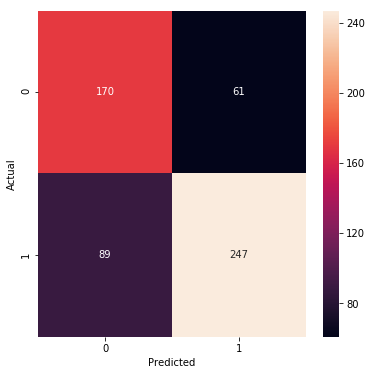

```
James Harden
Test Set
Accuracy: 0.7606679035250464
F1 Score: 0.7802385008517888

Classification Report:
               precision    recall  f1-score   support

           0       0.69      0.79      0.74       229
           1       0.83      0.74      0.78       310

    accuracy                           0.76       539
   macro avg       0.76      0.76      0.76       539
weighted avg       0.77      0.76      0.76       539
```

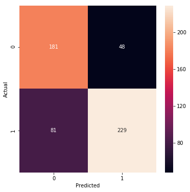

```
Stephen Curry
Test Set
Accuracy: 0.8256578947368421
F1 Score: 0.8417910447761194

Classification Report:
               precision    recall  f1-score   support

           0       0.75      0.87      0.81       126
           1       0.90      0.79      0.84       178

    accuracy                           0.83       304
   macro avg       0.82      0.83      0.82       304
weighted avg       0.84      0.83      0.83       304
```

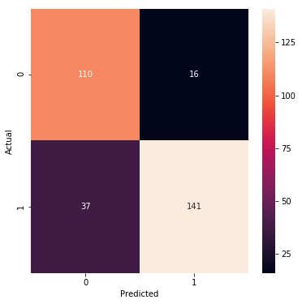

```python
output, feature_importances = shot_predictor(df, players, predictors, player_pipelines)
```

As a follow-up, the importance of each independent variable (predictor) is visualized for each player. It is interesting to note that each player has a slightly different feature importance profile. For LeBron James, his in-the-moment shot percentage (feature named game_shot_pct) is more important in relative terms than it is for Stephen Curry. This MAY indicate that James is more apt to be impacted by the psychological influence of his own cumulative playing quality at the time of each subsequent shot than Curry is.

The 'gambler's fallacy' would erroneously suggest that the probability of making a shot is somehow influenced by the previous shot - leading to a feeling of being 'hot' or 'cold'. While this is wrong from a statistical standpoint, it may be possible that the psychological influences of this fallacy are present however subliminal they may be.

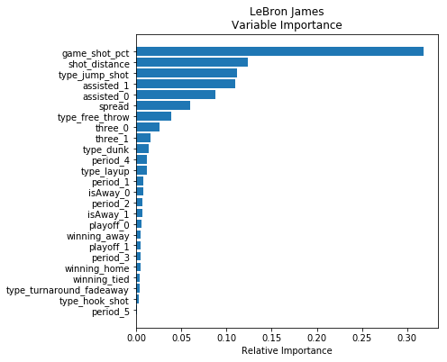

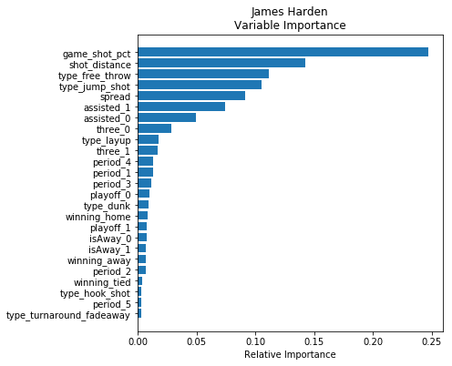

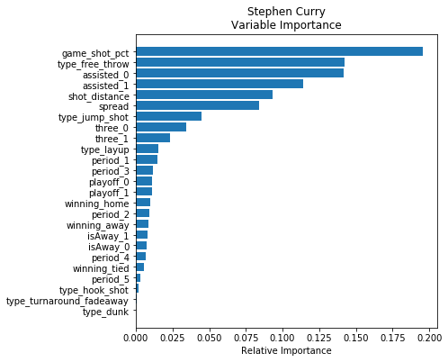

```python
for i in range(len(feature_importances)):

    feature_importance = feature_importances[i]

    sorted_idx = np.argsort(feature_importance)
    pos = np.arange(sorted_idx.shape[0]) + .5

    fig, ax = plt.subplots(figsize = (6,6))
    plt.barh(pos, feature_importance[sorted_idx], align='center')
    plt.yticks(pos, df[predictors].columns[sorted_idx])
    plt.xlabel('Relative Importance')
    plt.title(players[i] + '\nVariable Importance')

    plt.show()
```

## Finalize the output

To set up a final augmented dataframe, use the dataframe indices to JOIN in the other fields of interest e.g. date, game_id, game_time, play_id, player, and the court coordinates to be used for visualization purposes. Sort chronologically by date, player, gametime

```python
output = pd.merge(nba[['date', 'game_id', 'play_id', 'game_time', 'player', 'type', 'original_x', 'original_y']], output, left_index=True, right_index=True, how='inner')
```

```python
output = output.sort_values(['date','player', 'game_time'])
```

### View a random sample of the final data:

```python
output[['date', 'game_id', 'player', 'game_time', 'result_pred', 'type', 'missed_prob', 'made_prob', 'result_flag']].sample(n = 20, random_state = 0)
```

|  | date | game_id | player | game_time | result_pred | type | missed_prob | made_prob | result_flag |
| --- | --- | --- | --- | --- | --- | --- | --- | --- | --- |
| 1166 | 11/16/2017 | 21700216 | James Harden | 00:32:35 | 1 | free_throw | 0.096935 | 0.903065 | 1 |
| 2357 | 12/25/2017 | 21700494 | LeBron James | 00:11:12 | 0 | layup | 0.567326 | 0.432674 | 1 |
| 5326 | 4/6/2018 | 21701183 | LeBron James | 00:03:38 | 1 | layup | 0.199113 | 0.800887 | 1 |
| 1740 | 12/3/2017 | 21700338 | James Harden | 00:32:04 | 1 | layup | 0.239146 | 0.760854 | 1 |
| 6449 | 5/21/2018 | 41700304 | LeBron James | 00:23:49 | 1 | jump_shot | 0.225837 | 0.774163 | 1 |
| 4191 | 2/28/2018 | 21700917 | Stephen Curry | 00:11:56 | 0 | free_throw | 0.574894 | 0.425106 | 1 |
| 825 | 11/7/2017 | 21700149 | LeBron James | 00:38:55 | 1 | layup | 0.197409 | 0.802591 | 1 |
| 1959 | 12/11/2017 | 21700392 | James Harden | 00:01:42 | 1 | jump_shot | 0.300435 | 0.699565 | 1 |
| 281 | 10/24/2017 | 21700049 | LeBron James | 00:19:46 | 0 | jump_shot | 0.668082 | 0.331918 | 0 |
| 4417 | 3/7/2018 | 21700968 | James Harden | 00:00:38 | 0 | layup | 0.908458 | 0.091542 | 0 |
| 643 | 11/3/2017 | 21700122 | LeBron James | 00:04:57 | 1 | free_throw | 0.240716 | 0.759284 | 1 |
| 6423 | 5/20/2018 | 41700313 | Stephen Curry | 00:37:58 | 0 | jump_shot | 0.723864 | 0.276136 | 1 |
| 6507 | 5/22/2018 | 41700314 | Stephen Curry | 00:30:47 | 1 | jump_shot | 0.010797 | 0.989203 | 1 |
| 7036 | 6/8/2018 | 41700404 | Stephen Curry | 00:50:41 | 1 | jump_shot | 0.013145 | 0.986855 | 1 |
| 465 | 10/28/2017 | 21700080 | James Harden | 00:49:02 | 0 | jump_shot | 0.757015 | 0.242985 | 0 |
| 5082 | 3/28/2018 | 21701116 | LeBron James | 00:23:57 | 1 | free_throw | 0.477991 | 0.522009 | 0 |
| 1600 | 11/29/2017 | 21700308 | James Harden | 00:39:21 | 1 | free_throw | 0.399481 | 0.600519 | 1 |
| 2036 | 12/14/2017 | 21700415 | LeBron James | 00:21:21 | 1 | dunk | 0.185661 | 0.814339 | 1 |
| 4501 | 3/9/2018 | 21700979 | James Harden | 00:49:45 | 1 | layup | 0.194037 | 0.805963 | 1 |
| 503 | 10/29/2017 | 21700091 | Stephen Curry | 00:38:26 | 1 | layup | 0.008437 | 0.991563 | 1 |

### Visualize the predicted shot probability by player:

Finally various visualizations can be created using the extracted shot probabilities. As an example, the predicted probability of making a shot is visualized below using the court coordinates, and the 'made_prob' variable, faceted by player. This is simply one simple example of the output from this process can be used to derive game-time insights.

```python
fig = px.scatter(output, x="original_x", y="original_y", color="made_prob", facet_col="player")
fig.update_layout(
    title=go.layout.Title(
        text="Shot Probability Heat Map",
        xref="paper",
        x=0.5
    ))
fig.show()
```

[interactive chart not shown]

### Next Steps:

While this is an interesting preliminary workflow, there is more than can be done:

1. Add more data from other seasons for each player
2. Exclude 'free throw' shots as these are distinct from all other shot types. Possibly model these separately.
3. Deploy as a web application